# Fazendo mapas em R

8/22/2019

## Roteiro

1. Geoprocessamento e Sistemas de Informação Geográfica
2. Sistemas de projeção
3. Tipos de dados
4. Pacotes R utilizados
5. Exemplos para dados vetoriais
6. Exemplos para dados raster
   - Pacote *raster*
   - Pacote *stars*
7. Mapas dinâmicos

## O que temos em comum?

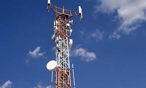

[figure not shown]

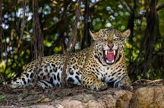

[figure not shown]

## Localização espacial

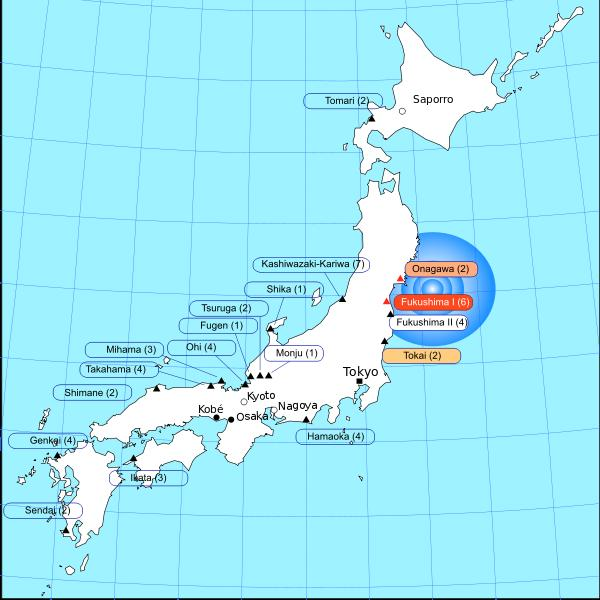

[figure not shown]

## Sistemas de Informação Geográfica (SIGs)

- Geoprocessamento
  - Tecnologias voltadas para a coleta e tratamento de informações espaciais
  - Inclui coleta de dados, armazenamento, manipulação, gerenciamento, análise, produção de novas informações etc
- Forte desenvolvimento incluindo soluções para o público em geral (Google maps)

## Sistemas de Informação Geográfica (SIGs)

Sistemas para processamento de dados gráficos e não gráficos, com ênfase em análises espaciais.

- *“Um conjunto manual ou computacional de procedimentos utilizados para armazenar e manipular dados georeferenciados” (Aronoff, 1989).*
- *“Conjunto poderoso de ferramentas para coletar, armazenar, recuperar, transformar e visualizar dados sobre o mundo real” (Burrough, 1986).*
- *“Um sistema de suporte à decisão que integra dados referenciados espacialmente num ambiente de respostas a problemas” (Cowen, 1988).*
- *“Um banco de dados indexados espacialmente, sobre o qual opera um conjunto de procedimentos para responder a consultas sobre entidades espaciais” (Smith et al., 1987)*

## Sistemas de Informação Geográfica (SIGs)

**Elementos básicos**  
- Hardware  
- Software  
- Dados  
- Profissionais  
- Métodos

**Funcionalidades**  
- Banco de dados espaciais e atributos  
- Sistemas para apresentação cartográfica  
- Edição de mapas  
- Análise geográfica  
- Processamento de imagens

## John Snow - Cólera no bairro Soho, Londres, 1854

[figure not shown]

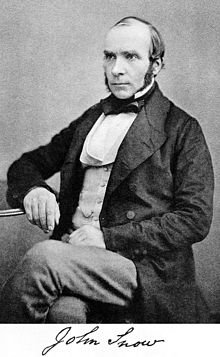

## Operações que podem ser feitas

- Distância
- Transformação de coordenadas
- Buffer
- Delimitação de bacias
- Superfície de custo
- Transformação de formato
- Álgebra de mapas
- Segmentação de imagens
- Recorte
- União (join)
- Classificação de imagens
  - Supervisionada
  - Não supervisionada
- …

## A Terra não é plana

[figure not shown]

- Sistema de Coordenadas (CRS - coordinate reference system)
  - Determinar a localização na superfície da Terra
  - Depende da representação da terra (esfera, elipsoide)
  - Coordenadas esféricas
  - Datum: WGS84 - utilizado pelo sistema GPS
  - Sirgas2000; SAD69; Corrego Alegre

## Projeção Cartográfica

- Coordenadas planas
- Distorce alguma característica
  - Área
  - Forma
  - Comprimento

[figure not shown]

## Pondo ordem na bagunça

- Importante que dados estejam no *mesmo sistema de projeção* para se fazer a análise
- Alguns SIGs fazem transformação automática.
- Código [EPSG](https://epsg.io/)
  - Catálogo de sistemas de projeção comumente utilizadas
  - Facilitar interoperabilidade
  - EPSG:4326 - Coordenadas Geográficas, WGS84
  - EPSG:32722 - UTM Zona 22 S, WGS84
  - EPSG:31982 - UTM Zona 22 S, Sirgas 2000

## Transformações de projeção / coordenadas

- Uso da biblioteca / software PROJ
  - https://proj.org/index.html
- Lista de projeções
  - https://proj.org/operations/projections/index.html
- Proj strings
  - +proj=merc +lat_ts=56.5 +ellps=GRS80

## Tipos de dados

### Diferentes formas de representar dados espaciais

**Vetorial**  
- Pontos, linhas polígonos  
- Topologia (vizinhança, sobreposição…)  
- Exatidão gráfica (ponto é sempre ponto)  
- Tabela de atributos associada  
- Shapefiles  
- GeoPackage  
- GeoJSON  
- PostGIS

**Matricial**  
- linhas / colunas  
- Pixel: menor unidade - resolução espacial  
- Estrutura simples  
- Grande volume de dados  
- GeoTIFF  
- IMG  
- NetCDF

## Vetor vs. Raster

[figure not shown]

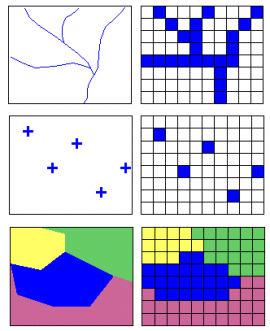

## Pacotes para dados geoespaciais

### Como tudo no R, muitos pacotes

[CRAN Task View: Analysis of Spatial Data](https://cran.r-project.org/web/views/Spatial.html)

- rgdal
- sp
- raster
- rgrass7
- rqgis
- sf
- stars
- gstats
- …

## Pacotes para dados geoespaciais

rgdal

- ler / escrever dados raster ou vetorias
- ligação com GDAL / OGR
- transformações de projeção

raster

- ler / escrever dados raster
- funções para processar dados
- utiliza rgdal e outras bibliotecas

sp

- classes e métodos para tratar dados espaciais

## Pacotes mais rescentes

sf

- Simple Features for R
- padrão OGC
- implementação mais moderna do *sp*
- segue *tidyverse*

stars

- Spatial Temporal Arrays
- Cubo de dados raster e vetorial
- segue *tidyverse*

https://github.com/r-spatial

Daniel: Em processo de transição do *raster* para o *stars*

## Referências

- [CRAN Task View: Analysis of Spatial Data](https://cran.r-project.org/web/views/Spatial.html)
- [Geocomputation with R](https://bookdown.org/robinlovelace/geocompr/)

## Fim introdução

- Dados vetoriais
- Pacote raster
- Pacote stars
- Mapas dinâmicos